# Portfolio Backtest and Optimisation

This notebook builds a 10-stock equity portfolio using Yahoo Finance data for 2020-2025, backtests the Bollinger Bands Mean Reversion strategy from the A2 Strategy document, and compares equal-weight, Sharpe-ratio optimised, and AI-generated optimised portfolios.

The selected stocks are actively traded large-cap US equities: AAPL, MSFT, AMZN, GOOGL, META, NVDA, JPM, XOM, UNH, and COST. They give exposure to technology, communication services, financials, energy, healthcare, and retail. Yahoo Finance data is accessed through `yfinance`, which documents `yf.download()` for downloading market data from Yahoo Finance's API for research and educational use: https://ranaroussi.github.io/yfinance/.

## Setup: Environment setup

Run this cell first if the selected notebook kernel does not already have the required packages. The cell first looks for the project virtual environment used to build this notebook. If packages are still missing, it installs only the missing packages into the current kernel.

```python
import importlib.util
import subprocess
import sys
from pathlib import Path

python_tag = f"python{sys.version_info.major}.{sys.version_info.minor}"
for root in [Path.cwd(), *Path.cwd().parents[:3]]:
    local_site_packages = root / "work" / "venv" / "lib" / python_tag / "site-packages"
    if local_site_packages.exists() and str(local_site_packages) not in sys.path:
        sys.path.insert(0, str(local_site_packages))
        print(f"Using local project packages from: {local_site_packages}")
        break

required_packages = {
    "numpy": "numpy",
    "pandas": "pandas",
    "matplotlib": "matplotlib",
    "seaborn": "seaborn",
    "scipy": "scipy",
    "yfinance": "yfinance",
    "IPython": "ipython",
}

missing_packages = [
    pip_name
    for import_name, pip_name in required_packages.items()
    if importlib.util.find_spec(import_name) is None
]

if missing_packages:
    print("Installing missing packages:", ", ".join(missing_packages))
    subprocess.check_call([sys.executable, "-m", "pip", "install", *missing_packages])
else:
    print("All required packages are available in this kernel.")
```

```
All required packages are available in this kernel.
```

## Setup: Imports and configuration

The analysis uses standard Python data libraries and `scipy.optimize.minimize` for both optimisation methods. I use a zero risk-free rate so that the Sharpe-ratio comparison focuses on relative portfolio construction rather than interest-rate assumptions.

```python
import logging
import warnings

logging.getLogger("yfinance").setLevel(logging.ERROR)
warnings.filterwarnings("ignore", category=FutureWarning)

import numpy as np
import pandas as pd
import matplotlib.pyplot as plt
import seaborn as sns
import yfinance as yf

from scipy.optimize import minimize
from IPython.display import Markdown, display

pd.set_option("display.max_columns", 20)
pd.set_option("display.width", 140)
pd.options.display.float_format = "{:,.4f}".format

sns.set_theme(style="whitegrid", context="notebook")

TICKERS = ["AAPL", "MSFT", "AMZN", "GOOGL", "META", "NVDA", "JPM", "XOM", "UNH", "COST"]
START_DATE = "2020-01-01"
END_DATE = "2026-01-01"  # yfinance end dates are exclusive, so this includes 2025-12-31.
TRADING_DAYS = 252
RISK_FREE_RATE = 0.0
MAX_WEIGHT = 0.35
```

## Data Retrieval

I download all ten stocks in one call and keep the result as a single Pandas DataFrame. The columns have two levels: the price field and the ticker. The date range uses 2026-01-01 as the exclusive end date, which includes the final trading days of 2025.

```python
raw_data = yf.download(
    TICKERS,
    start=START_DATE,
    end=END_DATE,
    auto_adjust=False,
    progress=False,
    group_by="column",
    threads=True,
)

if raw_data.empty:
    raise ValueError("No data returned from Yahoo Finance. Check network access or ticker symbols.")

raw_data.index = pd.to_datetime(raw_data.index).tz_localize(None)
raw_data = raw_data.sort_index()

expected_columns = pd.MultiIndex.from_product(
    [["Open", "High", "Low", "Close", "Adj Close", "Volume"], TICKERS]
)
missing_columns = [column for column in expected_columns if column not in raw_data.columns]
if missing_columns:
    raise ValueError(f"Missing expected columns from Yahoo Finance: {missing_columns[:5]}")

raw_data = raw_data.loc[:, expected_columns]

print(f"Rows downloaded: {raw_data.shape[0]:,}")
print(f"Columns downloaded: {raw_data.shape[1]:,}")
print(f"Date range: {raw_data.index.min().date()} to {raw_data.index.max().date()}")
display(raw_data.head(3))
```

```
Rows downloaded: 1,508
Columns downloaded: 60
Date range: 2020-01-02 to 2025-12-31
```

| Price Ticker Date | Open AAPL | Open MSFT | Open AMZN | Open GOOGL | Open META | Open NVDA | Open JPM | Open XOM | Open UNH | Open COST | ... | Volume AAPL | Volume MSFT | Volume AMZN | Volume GOOGL | Volume META | Volume NVDA | Volume JPM | Volume XOM | Volume UNH | Volume COST |
| --- | --- | --- | --- | --- | --- | --- | --- | --- | --- | --- | --- | --- | --- | --- | --- | --- | --- | --- | --- | --- | --- |
| 2020-01-02 | 74.0600 | 158.7800 | 93.7500 | 67.4205 | 206.7500 | 5.9688 | 139.7900 | 70.2400 | 293.9800 | 294.0600 | ... | 135480400 | 22622100 | 80580000 | 27278000 | 12077100 | 237536000 | 10803700 | 12456400 | 2543400 | 2103600 |
| 2020-01-03 | 74.2875 | 158.3200 | 93.2250 | 67.4000 | 207.2100 | 5.8775 | 137.5000 | 71.3400 | 287.2700 | 290.0500 | ... | 146322800 | 21116200 | 75288000 | 23408000 | 11188400 | 205384000 | 10386800 | 17386900 | 2711400 | 1926000 |
| 2020-01-06 | 73.4475 | 157.0800 | 93.0000 | 67.5815 | 206.7000 | 5.8080 | 136.5600 | 70.3200 | 288.0000 | 290.5500 | ... | 118387200 | 20813700 | 81236000 | 46768000 | 17058900 | 262636000 | 10259000 | 20081900 | 3079100 | 2655100 |

3 rows × 60 columns

## Data Retrieval: Data cleaning and consistency checks

The main consistency checks are duplicated dates, missing values, and whether all requested tickers were returned. If missing prices appeared, I would forward-fill isolated price fields because a missing vendor observation should not create a false return. Any remaining rows with missing values would be removed because they cannot be filled without using future information. In this download the data is already complete, so the checks demonstrate that no filling is needed.

For return calculations I use adjusted close prices. Adjusted close is used because it reflects corporate actions such as dividends and splits, which matter over a six-year period: https://www.investopedia.com/ask/answers/06/adjustedclosingprice.asp.

```python
duplicate_rows = int(raw_data.index.duplicated().sum())
missing_before = int(raw_data.isna().sum().sum())

clean_data = raw_data.loc[~raw_data.index.duplicated(keep="first")].copy()

if missing_before > 0:
    price_fields = {"Open", "High", "Low", "Close", "Adj Close"}
    price_columns = [column for column in clean_data.columns if column[0] in price_fields]
    clean_data.loc[:, price_columns] = clean_data.loc[:, price_columns].ffill()
    clean_data = clean_data.dropna(how="any")

missing_after = int(clean_data.isna().sum().sum())

cleaning_summary = pd.DataFrame(
    {
        "Check": [
            "Rows before cleaning",
            "Rows after cleaning",
            "Duplicate rows removed",
            "Missing values before cleaning",
            "Missing values after cleaning",
        ],
        "Value": [
            raw_data.shape[0],
            clean_data.shape[0],
            duplicate_rows,
            missing_before,
            missing_after,
        ],
    }
)

display(cleaning_summary)
```

|  | Check | Value |
| --- | --- | --- |
| 0 | Rows before cleaning | 1508 |
| 1 | Rows after cleaning | 1508 |
| 2 | Duplicate rows removed | 0 |
| 3 | Missing values before cleaning | 0 |
| 4 | Missing values after cleaning | 0 |

Interpretation: the raw Yahoo Finance pull is clean: there are no duplicated dates and no missing observations across the OHLCV fields. This matters because the later strategy and optimisation results are not being driven by artificial price jumps from imputed data. I can therefore treat differences in returns as market outcomes rather than data-cleaning artefacts.

## Data Exploration

The wide closing-price DataFrame below has one column per stock. I show the head and tail to verify the start and end of the requested sample, then plot all ten closing-price series together.

```python
close_prices = clean_data["Close"].loc[:, TICKERS]
adj_close = clean_data["Adj Close"].loc[:, TICKERS]

print("Head of wide closing-price DataFrame:")
display(close_prices.head())

print("Tail of wide closing-price DataFrame:")
display(close_prices.tail())
```

```
Head of wide closing-price DataFrame:
```

| Ticker Date | AAPL | MSFT | AMZN | GOOGL | META | NVDA | JPM | XOM | UNH | COST |
| --- | --- | --- | --- | --- | --- | --- | --- | --- | --- | --- |
| 2020-01-02 | 75.0875 | 160.6200 | 94.9005 | 68.4340 | 209.7800 | 5.9977 | 141.0900 | 70.9000 | 292.5000 | 291.4900 |
| 2020-01-03 | 74.3575 | 158.6200 | 93.7485 | 68.0760 | 208.6700 | 5.9018 | 138.3400 | 70.3300 | 289.5400 | 291.7300 |
| 2020-01-06 | 74.9500 | 159.0300 | 95.1440 | 69.8905 | 212.6000 | 5.9265 | 138.2300 | 70.8700 | 291.5500 | 291.8100 |
| 2020-01-07 | 74.5975 | 157.5800 | 95.3430 | 69.7555 | 213.0600 | 5.9983 | 135.8800 | 70.2900 | 289.7900 | 291.3500 |
| 2020-01-08 | 75.7975 | 160.0900 | 94.5985 | 70.2520 | 215.2200 | 6.0095 | 136.9400 | 69.2300 | 295.9000 | 294.6900 |

```
Tail of wide closing-price DataFrame:
```

| Ticker Date | AAPL | MSFT | AMZN | GOOGL | META | NVDA | JPM | XOM | UNH | COST |
| --- | --- | --- | --- | --- | --- | --- | --- | --- | --- | --- |
| 2025-12-24 | 273.8100 | 488.0200 | 232.3800 | 314.0900 | 667.5500 | 188.6100 | 329.1700 | 119.2200 | 327.5800 | 871.8600 |
| 2025-12-26 | 273.4000 | 487.7100 | 232.5200 | 313.5100 | 663.2900 | 190.5300 | 327.9100 | 119.1100 | 331.8300 | 873.3500 |
| 2025-12-29 | 273.7600 | 487.1000 | 232.0700 | 313.5600 | 658.6900 | 188.2200 | 323.7500 | 120.5300 | 328.9400 | 867.8400 |
| 2025-12-30 | 273.0800 | 487.4800 | 232.5300 | 313.8500 | 665.9500 | 187.5400 | 323.4200 | 120.9900 | 332.1600 | 865.6500 |
| 2025-12-31 | 271.8600 | 483.6200 | 230.8200 | 313.0000 | 660.0900 | 186.5000 | 322.2200 | 120.3400 | 330.1100 | 862.3400 |

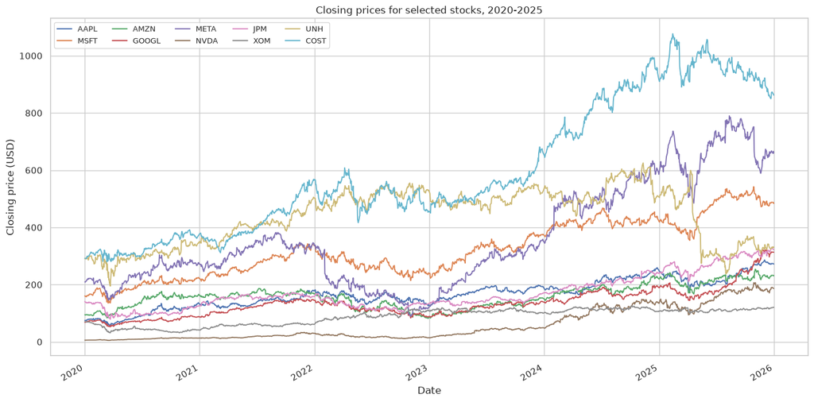

```python
ax = close_prices.plot(figsize=(14, 7), linewidth=1.4)
ax.set_title("Closing prices for selected stocks, 2020-2025")
ax.set_xlabel("Date")
ax.set_ylabel("Closing price (USD)")
ax.legend(ncol=5, fontsize=9)
plt.tight_layout()
plt.show()

price_change = close_prices.iloc[-1] / close_prices.iloc[0] - 1
top_price_names = price_change.sort_values(ascending=False).head(3).index.tolist()
worst_price_name = price_change.idxmin()
top_price_text = ", ".join(f"{ticker} ({price_change[ticker]:.2%})" for ticker in top_price_names)
```

Interpretation: the strongest raw closing-price increases are NVDA (3009.50%), GOOGL (357.38%), AAPL (262.06%), while UNH is the weakest at 12.86%. The important point is not simply that some stocks rose more than others; it is that the return distribution is highly uneven. That creates a portfolio construction problem: equal weighting captures some of the winners, but it also spends capital on weaker names that dilute the contribution from the strongest compounders. The optimisation stage should therefore be judged by whether it improves this capital allocation without becoming an uncontrolled bet on a single historical winner. The return calculations below use adjusted close prices to avoid distortion from splits and dividends.

## Trading Strategy

The A2 Strategy document defines a 20-day simple moving average as the middle band, upper and lower bands at two standard deviations from the middle band, long entry when price closes below the lower band, short entry when price closes above the upper band, long exit when price rises back to the middle band, and short exit when price falls back to the middle band.

The code below implements that rule as a stateful backtest. A position is held until its exit condition is met. Strategy returns are calculated using yesterday's position multiplied by today's simple daily return, which avoids look-ahead bias.

```python
def bollinger_mean_reversion_backtest(prices, window=20, num_std=2.0):
    simple_returns = prices.pct_change().dropna()

    entry_signals = pd.DataFrame(0.0, index=prices.index, columns=prices.columns)
    exit_signals = pd.DataFrame(0.0, index=prices.index, columns=prices.columns)
    positions = pd.DataFrame(0.0, index=prices.index, columns=prices.columns)
    strategy_returns = pd.DataFrame(0.0, index=simple_returns.index, columns=prices.columns)
    bands = {}

    for ticker in prices.columns:
        price = prices[ticker]
        middle_band = price.rolling(window=window).mean()
        rolling_std = price.rolling(window=window).std()
        upper_band = middle_band + num_std * rolling_std
        lower_band = middle_band - num_std * rolling_std

        ticker_entries = pd.Series(0.0, index=price.index)
        ticker_exits = pd.Series(0.0, index=price.index)
        ticker_positions = pd.Series(0.0, index=price.index)

        for i in range(window, len(price)):
            previous_position = ticker_positions.iloc[i - 1]
            current_price = price.iloc[i]
            current_middle = middle_band.iloc[i]
            current_upper = upper_band.iloc[i]
            current_lower = lower_band.iloc[i]

            if previous_position == 0:
                if current_price < current_lower:
                    ticker_entries.iloc[i] = 1.0
                    ticker_positions.iloc[i] = 1.0
                elif current_price > current_upper:
                    ticker_entries.iloc[i] = -1.0
                    ticker_positions.iloc[i] = -1.0
            elif previous_position == 1:
                if current_price >= current_middle:
                    ticker_exits.iloc[i] = 1.0
                    ticker_positions.iloc[i] = 0.0
                else:
                    ticker_positions.iloc[i] = 1.0
            elif previous_position == -1:
                if current_price <= current_middle:
                    ticker_exits.iloc[i] = -1.0
                    ticker_positions.iloc[i] = 0.0
                else:
                    ticker_positions.iloc[i] = -1.0

        entry_signals[ticker] = ticker_entries
        exit_signals[ticker] = ticker_exits
        positions[ticker] = ticker_positions
        strategy_returns[ticker] = ticker_positions.shift(1).reindex(simple_returns.index).fillna(0.0) * simple_returns[ticker]

        bands[ticker] = pd.DataFrame(
            {
                "Price": price,
                "Middle Band": middle_band,
                "Upper Band": upper_band,
                "Lower Band": lower_band,
                "Entry Signal": ticker_entries,
                "Exit Signal": ticker_exits,
                "Position": ticker_positions,
            }
        )

    return simple_returns, strategy_returns, entry_signals, exit_signals, positions, bands


simple_returns, strategy_returns, entry_signals, exit_signals, positions, bands = bollinger_mean_reversion_backtest(adj_close)

print("Simple daily returns, first five rows:")
display(simple_returns.head().style.format("{:.3%}"))

print("Strategy daily returns, first five rows:")
display(strategy_returns.head().style.format("{:.3%}"))
```

```
Simple daily returns, first five rows:
```

| Ticker Date | AAPL | MSFT | AMZN | GOOGL | META | NVDA | JPM | XOM | UNH | COST |
| --- | --- | --- | --- | --- | --- | --- | --- | --- | --- | --- |
| 2020-01-03 00:00:00 | -0.972% | -1.245% | -1.214% | -0.523% | -0.529% | -1.601% | -1.320% | -0.804% | -1.012% | 0.082% |
| 2020-01-06 00:00:00 | 0.797% | 0.258% | 1.489% | 2.665% | 1.883% | 0.419% | -0.080% | 0.768% | 0.694% | 0.027% |
| 2020-01-07 00:00:00 | -0.470% | -0.912% | 0.209% | -0.193% | 0.216% | 1.211% | -1.700% | -0.818% | -0.604% | -0.158% |
| 2020-01-08 00:00:00 | 1.609% | 1.593% | -0.781% | 0.712% | 1.014% | 0.188% | 0.780% | -1.508% | 2.108% | 1.146% |
| 2020-01-09 00:00:00 | 2.124% | 1.249% | 0.480% | 1.050% | 1.431% | 1.098% | 0.365% | 0.766% | -0.568% | 1.605% |

```
Strategy daily returns, first five rows:
```

| Ticker Date | AAPL | MSFT | AMZN | GOOGL | META | NVDA | JPM | XOM | UNH | COST |
| --- | --- | --- | --- | --- | --- | --- | --- | --- | --- | --- |
| 2020-01-03 00:00:00 | -0.000% | -0.000% | -0.000% | -0.000% | -0.000% | -0.000% | -0.000% | -0.000% | -0.000% | 0.000% |
| 2020-01-06 00:00:00 | 0.000% | 0.000% | 0.000% | 0.000% | 0.000% | 0.000% | -0.000% | 0.000% | 0.000% | 0.000% |
| 2020-01-07 00:00:00 | -0.000% | -0.000% | 0.000% | -0.000% | 0.000% | 0.000% | -0.000% | -0.000% | -0.000% | -0.000% |
| 2020-01-08 00:00:00 | 0.000% | 0.000% | -0.000% | 0.000% | 0.000% | 0.000% | 0.000% | -0.000% | 0.000% | 0.000% |
| 2020-01-09 00:00:00 | 0.000% | 0.000% | 0.000% | 0.000% | 0.000% | 0.000% | 0.000% | 0.000% | -0.000% | 0.000% |

```python
signal_summary = pd.DataFrame(
    {
        "Long entries": (entry_signals == 1).sum(),
        "Short entries": (entry_signals == -1).sum(),
        "Long exits": (exit_signals == 1).sum(),
        "Short exits": (exit_signals == -1).sum(),
        "Days long": (positions == 1).sum(),
        "Days short": (positions == -1).sum(),
        "Days flat": (positions == 0).sum(),
    }
)

display(signal_summary)

total_entries = int((entry_signals != 0).sum().sum())
total_exits = int((exit_signals != 0).sum().sum())
average_exposure = (positions != 0).mean().mean()
most_traded_ticker = (entry_signals != 0).sum().idxmax()
most_exposed_ticker = (positions != 0).mean().idxmax()
```

| Ticker | Long entries | Short entries | Long exits | Short exits | Days long | Days short | Days flat |
| --- | --- | --- | --- | --- | --- | --- | --- |
| AAPL | 23 | 28 | 23 | 28 | 286 | 596 | 626 |
| MSFT | 25 | 26 | 25 | 26 | 276 | 506 | 726 |
| AMZN | 20 | 31 | 20 | 31 | 268 | 490 | 750 |
| GOOGL | 20 | 30 | 20 | 30 | 257 | 559 | 692 |
| META | 24 | 30 | 24 | 29 | 282 | 532 | 694 |
| NVDA | 25 | 29 | 25 | 28 | 230 | 587 | 691 |
| JPM | 24 | 26 | 24 | 25 | 284 | 444 | 780 |
| XOM | 24 | 29 | 24 | 29 | 295 | 403 | 810 |
| UNH | 32 | 31 | 32 | 31 | 372 | 428 | 708 |
| COST | 19 | 25 | 18 | 25 | 226 | 528 | 754 |

Interpretation: the stateful strategy generated 521 entries and 517 exits across the ten stocks. Average market exposure was 52.05% of stock-days, so the strategy is not a replacement for equity exposure; it is a conditional trading overlay. UNH generated the most entry signals, while AAPL had the highest proportion of days in a position. The investment implication is that the strategy must earn a high payoff per trade to beat buy-and-hold, because it gives up many days of market participation. In a period where several stocks trended strongly upward, that opportunity cost is a serious hurdle for a mean-reversion rule.

| Ticker | Buy and hold cumulative return | Strategy cumulative return | Strategy minus buy and hold |
| --- | --- | --- | --- |
| NVDA | 3023.39% | -38.41% | -3061.80% |
| GOOGL | 360.83% | -40.12% | -400.95% |
| AAPL | 275.14% | -41.48% | -316.63% |
| COST | 223.58% | -40.31% | -263.89% |
| MSFT | 217.12% | 36.38% | -180.74% |
| META | 216.86% | -33.02% | -249.88% |
| JPM | 169.47% | 19.43% | -150.04% |
| AMZN | 143.22% | 14.30% | -128.92% |
| XOM | 124.26% | 18.12% | -106.14% |
| UNH | 24.46% | 118.82% | 94.36% |

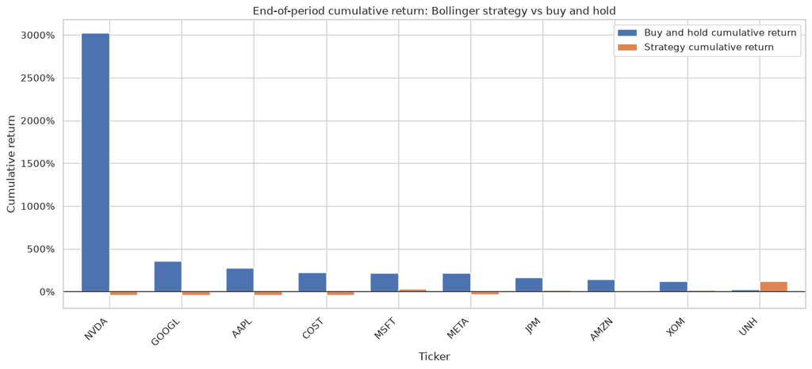

```python
buy_hold_cumulative = (1 + simple_returns).prod() - 1
strategy_cumulative = (1 + strategy_returns).prod() - 1

backtest_summary = pd.DataFrame(
    {
        "Buy and hold cumulative return": buy_hold_cumulative,
        "Strategy cumulative return": strategy_cumulative,
        "Strategy minus buy and hold": strategy_cumulative - buy_hold_cumulative,
    }
).sort_values("Buy and hold cumulative return", ascending=False)

display(backtest_summary.style.format("{:.2%}"))

ax = backtest_summary[["Buy and hold cumulative return", "Strategy cumulative return"]].plot(
    kind="bar",
    figsize=(13, 6),
    width=0.78,
)
ax.set_title("End-of-period cumulative return: Bollinger strategy vs buy and hold")
ax.set_ylabel("Cumulative return")
ax.axhline(0, color="black", linewidth=0.8)
ax.yaxis.set_major_formatter(plt.FuncFormatter(lambda value, _: f"{value:.0%}"))
plt.xticks(rotation=45, ha="right")
plt.tight_layout()
plt.show()

strategy_outperformers = backtest_summary.index[
    backtest_summary["Strategy minus buy and hold"] > 0
].tolist()
best_strategy_ticker = strategy_cumulative.idxmax()
best_buy_hold_ticker = buy_hold_cumulative.idxmax()
worst_strategy_gap_ticker = (strategy_cumulative - buy_hold_cumulative).idxmin()
median_strategy_gap = (strategy_cumulative - buy_hold_cumulative).median()
```

Interpretation: the strategy outperformed buy and hold for UNH. The best strategy result was UNH with a cumulative return of 118.82%. However, the median strategy-minus-buy-and-hold gap was -215.31%. That median gap is the key evidence: the strategy has stock-specific value, but it is not robust enough to apply across the whole portfolio. I would therefore treat the trading rule as a selective overlay only where the backtest shows clear incremental value.

## Portfolio Management

I visualise the correlation matrix of simple daily adjusted-close returns. Then I create an equal-weight portfolio with 10% in each stock and calculate annualised return and annualised volatility.

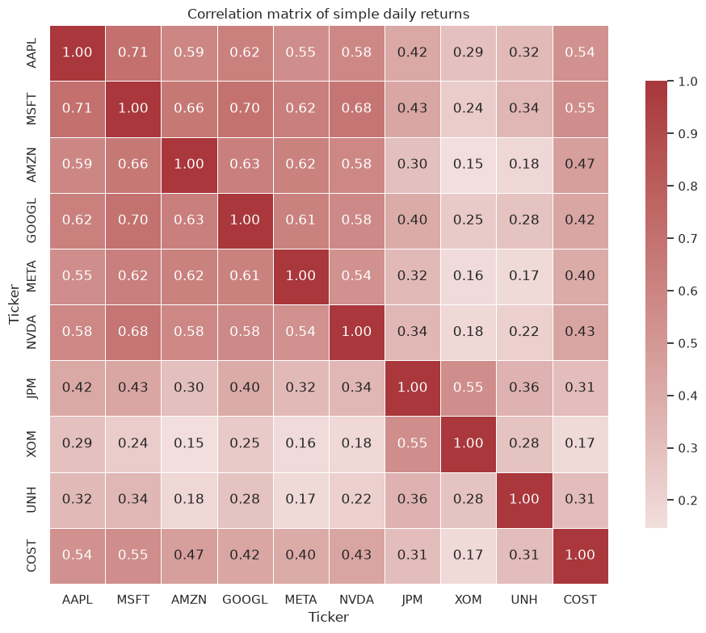

```python
correlation_matrix = simple_returns.corr()

plt.figure(figsize=(10, 8))
sns.heatmap(
    correlation_matrix,
    annot=True,
    fmt=".2f",
    cmap="vlag",
    center=0,
    square=True,
    linewidths=0.5,
    cbar_kws={"shrink": 0.8},
)
plt.title("Correlation matrix of simple daily returns")
plt.tight_layout()
plt.show()

mean_correlation = correlation_matrix.where(~np.eye(len(TICKERS), dtype=bool)).stack().mean()
corr_pairs = correlation_matrix.where(np.triu(np.ones(correlation_matrix.shape), k=1).astype(bool)).stack()
highest_corr_pair = corr_pairs.idxmax()
lowest_corr_pair = corr_pairs.idxmin()
```

Interpretation: the average pairwise correlation is 0.42. The most correlated pair is AAPL and MSFT at 0.71, while the lowest correlation is AMZN and XOM at 0.15. This tells me diversification is real but incomplete. The portfolio should reduce idiosyncratic single-stock risk, but it will still be exposed to broad equity drawdowns. That is why optimisation should not only chase the highest-return names; it should also consider whether the resulting weights increase exposure to the same underlying market factor.

```python
def annualised_return(returns):
    return returns.mean() * TRADING_DAYS


def annualised_volatility(returns):
    return returns.std() * np.sqrt(TRADING_DAYS)


def portfolio_returns(returns, weights):
    return returns @ weights


def max_drawdown(returns):
    cumulative = (1 + returns).cumprod()
    running_peak = cumulative.cummax()
    drawdown = cumulative / running_peak - 1
    return drawdown.min()


def performance_stats(returns):
    ann_return = annualised_return(returns)
    ann_vol = annualised_volatility(returns)
    sharpe = (ann_return - RISK_FREE_RATE) / ann_vol
    cumulative_return = (1 + returns).prod() - 1
    return pd.Series(
        {
            "Cumulative return": cumulative_return,
            "Annualised return": ann_return,
            "Annualised volatility": ann_vol,
            "Maximum drawdown": max_drawdown(returns),
            "Sharpe ratio": sharpe,
        }
    )


stats_format = {
    "Cumulative return": "{:.2%}",
    "Annualised return": "{:.2%}",
    "Annualised volatility": "{:.2%}",
    "Maximum drawdown": "{:.2%}",
    "Sharpe ratio": "{:.2f}",
}

equal_weights = pd.Series(1 / len(TICKERS), index=TICKERS, name="Equal weight")
equal_weight_returns = portfolio_returns(simple_returns, equal_weights)
equal_weight_stats = performance_stats(equal_weight_returns)

display(equal_weights.to_frame().T.style.format("{:.1%}"))
display(equal_weight_stats.to_frame().T.style.format(stats_format))
```

|  | AAPL | MSFT | AMZN | GOOGL | META | NVDA | JPM | XOM | UNH | COST |
| --- | --- | --- | --- | --- | --- | --- | --- | --- | --- | --- |
| Equal weight | 10.0% | 10.0% | 10.0% | 10.0% | 10.0% | 10.0% | 10.0% | 10.0% | 10.0% | 10.0% |

|  | Cumulative return | Annualised return | Annualised volatility | Maximum drawdown | Sharpe ratio |
| --- | --- | --- | --- | --- | --- |
| 0 | 335.62% | 27.57% | 24.29% | -30.72% | 1.14 |

Interpretation: the equal-weight portfolio produced an annualised return of 27.57% with annualised volatility of 24.29%, a maximum drawdown of -30.72%, and a Sharpe ratio of 1.14. This is a strong baseline, not a weak straw man. Because equal weighting already earns attractive return with broad exposure, an optimiser must add value after considering concentration and drawdown. If an optimised portfolio only improves return by loading into a few historical winners, I would not regard that as a sufficient investment case.

## Portfolio Optimisation: Return-basis decision

The optimisation must compare portfolios on a like-for-like basis. I use a per-stock rule: if the Bollinger strategy beats buy and hold for a stock, I use that stock's strategy returns; otherwise I use its simple buy-and-hold returns. This follows the assessment guidance and lets the backtest evidence determine whether the firm should trade or hold each stock.

```python
return_basis = pd.Series("Buy and hold", index=TICKERS, name="Selected return basis")
return_basis[strategy_cumulative > buy_hold_cumulative] = "Strategy"

selected_returns = simple_returns.copy()
for ticker in TICKERS:
    if return_basis[ticker] == "Strategy":
        selected_returns[ticker] = strategy_returns[ticker]

basis_table = pd.concat(
    [
        return_basis,
        buy_hold_cumulative.rename("Buy and hold cumulative return"),
        strategy_cumulative.rename("Strategy cumulative return"),
    ],
    axis=1,
)

display(basis_table.style.format({
    "Buy and hold cumulative return": "{:.2%}",
    "Strategy cumulative return": "{:.2%}",
}))

strategy_count = int((return_basis == "Strategy").sum())
buy_hold_count = int((return_basis == "Buy and hold").sum())
strategy_word = "stock is" if strategy_count == 1 else "stocks are"
buy_hold_word = "stock is" if buy_hold_count == 1 else "stocks are"
```

|  | Selected return basis | Buy and hold cumulative return | Strategy cumulative return |
| --- | --- | --- | --- |
| AAPL | Buy and hold | 275.14% | -41.48% |
| MSFT | Buy and hold | 217.12% | 36.38% |
| AMZN | Buy and hold | 143.22% | 14.30% |
| GOOGL | Buy and hold | 360.83% | -40.12% |
| META | Buy and hold | 216.86% | -33.02% |
| NVDA | Buy and hold | 3023.39% | -38.41% |
| JPM | Buy and hold | 169.47% | 19.43% |
| XOM | Buy and hold | 124.26% | 18.12% |
| UNH | Strategy | 24.46% | 118.82% |
| COST | Buy and hold | 223.58% | -40.31% |

Interpretation: 1 stock is assigned to the strategy-return basis and 9 stocks are assigned to buy-and-hold returns. This decision is deliberately evidence-led: the strategy is only used where it beats the passive alternative. All portfolios below use this same selected return matrix, so differences in performance come from weighting decisions rather than from changing the return definition between portfolios. That makes the optimisation comparison fairer and prevents the analysis from rewarding one portfolio simply because it was tested on a more favourable return series.

## Portfolio Optimisation: Sharpe Ratio optimisation

The textbook optimiser maximises the Sharpe ratio by minimising its negative value. The constraints are long-only weights, full investment, and a maximum 35% weight per stock. The Sharpe ratio is a standard measure of excess return per unit of volatility: https://www.investopedia.com/terms/s/sharperatio.asp. SciPy documents `minimize` as a scalar objective-function minimisation routine that accepts bounds and constraints: https://docs.scipy.org/doc/scipy/reference/generated/scipy.optimize.minimize.html.

```python
def negative_sharpe(weights, returns):
    port_returns = portfolio_returns(returns, weights)
    ann_return = annualised_return(port_returns)
    ann_vol = annualised_volatility(port_returns)

    if ann_vol == 0 or np.isnan(ann_vol):
        return np.inf

    return -((ann_return - RISK_FREE_RATE) / ann_vol)


def optimise_sharpe_ratio(returns, max_weight=MAX_WEIGHT):
    n_assets = returns.shape[1]
    initial_guess = np.repeat(1 / n_assets, n_assets)
    bounds = tuple((0.0, max_weight) for _ in range(n_assets))
    constraints = ({"type": "eq", "fun": lambda weights: np.sum(weights) - 1.0},)

    result = minimize(
        negative_sharpe,
        initial_guess,
        args=(returns,),
        method="SLSQP",
        bounds=bounds,
        constraints=constraints,
        options={"maxiter": 1000, "ftol": 1e-12},
    )

    if not result.success:
        raise RuntimeError(f"Sharpe optimisation failed: {result.message}")

    return pd.Series(result.x, index=returns.columns, name="Sharpe optimised")


sharpe_weights = optimise_sharpe_ratio(selected_returns)
sharpe_returns = portfolio_returns(selected_returns, sharpe_weights)
sharpe_stats = performance_stats(sharpe_returns)

display(sharpe_weights.to_frame().T.style.format("{:.2%}"))
display(sharpe_stats.to_frame().T.style.format(stats_format))

sharpe_top_weights = sharpe_weights.sort_values(ascending=False).head(3)
sharpe_top_text = ", ".join(f"{ticker} ({weight:.2%})" for ticker, weight in sharpe_top_weights.items())
sharpe_concentration = np.sum(sharpe_weights ** 2)
equal_concentration = np.sum(equal_weights ** 2)
```

| Ticker | AAPL | MSFT | AMZN | GOOGL | META | NVDA | JPM | XOM | UNH | COST |
| --- | --- | --- | --- | --- | --- | --- | --- | --- | --- | --- |
| Sharpe optimised | 0.00% | 0.00% | 0.00% | 4.40% | 0.00% | 30.61% | 0.00% | 11.50% | 30.56% | 22.92% |

|  | Cumulative return | Annualised return | Annualised volatility | Maximum drawdown | Sharpe ratio |
| --- | --- | --- | --- | --- | --- |
| 0 | 616.13% | 35.64% | 23.29% | -23.98% | 1.53 |

Interpretation: the Sharpe optimiser concentrates most heavily in NVDA (30.62%), UNH (30.56%), COST (22.92%). Its Sharpe ratio is 1.53, compared with 1.14 for the equal-weight portfolio. The Herfindahl concentration score rises from 0.10 for equal weighting to 0.25, so the improvement in risk-adjusted return is not free: it is purchased with materially higher concentration. My judgement is that the Sharpe portfolio is attractive, but only because the concentration is capped and the drawdown profile also improves. Without the maximum-weight constraint, this optimiser would be too vulnerable to overfitting the strongest historical winners.

## Portfolio Optimisation: AI-generated optimisation

The A2 Optimisation document asks for a generative-AI portfolio optimiser that uses `NumPy`, `Pandas`, and `SciPy` only, and that uses `scipy.optimize.minimize`. I asked for strategies beyond a standard Sharpe-ratio maximisation and selected a downside-aware diversification optimiser.

The AI-generated idea is to maximise a utility score that rewards annualised return, penalises downside deviation, and penalises concentration. This is useful because the Sharpe optimiser can put large weights in a few strong stocks. The AI objective keeps the same long-only and maximum-weight constraints, but it explicitly rewards a smoother and more diversified portfolio.

```python
def downside_deviation(returns):
    # Downside deviation is calculated only from negative returns.
    # It is useful here because investors normally care more about losses than upside volatility.
    downside_returns = np.minimum(returns, 0.0)
    return np.sqrt(np.mean(downside_returns ** 2) * TRADING_DAYS)


def ai_downside_diversification_objective(weights, returns, downside_penalty=1.50, concentration_penalty=0.08):
    # Convert the candidate weights into one daily portfolio return series.
    # The optimiser changes the weights; this line translates those weights into observable portfolio returns.
    port_returns = portfolio_returns(returns, weights)

    # Annualised return is the reward term. Higher is better, so the final minimisation uses its negative.
    ann_return = annualised_return(port_returns)

    # Downside deviation is the first risk penalty. It focuses on negative daily returns only.
    # This makes the generated optimiser different from the Sharpe optimiser, which treats upside and downside volatility equally.
    downside_risk = downside_deviation(port_returns)

    # The sum of squared weights is a simple concentration penalty.
    # A portfolio with one or two very large holdings has a higher value than a spread-out portfolio.
    concentration = np.sum(weights ** 2)

    # The score is a utility function: return is good, downside risk and concentration are bad.
    # SciPy minimises functions, so the objective returns the negative of the utility score.
    utility = ann_return - downside_penalty * downside_risk - concentration_penalty * concentration
    return -utility


def optimise_ai_downside_diversification(returns, max_weight=MAX_WEIGHT):
    n_assets = returns.shape[1]
    initial_guess = np.repeat(1 / n_assets, n_assets)

    # Bounds enforce a long-only portfolio and prevent the AI optimiser from becoming a single-stock portfolio.
    bounds = tuple((0.0, max_weight) for _ in range(n_assets))

    # The equality constraint keeps the portfolio fully invested.
    constraints = ({"type": "eq", "fun": lambda weights: np.sum(weights) - 1.0},)

    result = minimize(
        ai_downside_diversification_objective,
        initial_guess,
        args=(returns,),
        method="SLSQP",
        bounds=bounds,
        constraints=constraints,
        options={"maxiter": 1000, "ftol": 1e-12},
    )

    if not result.success:
        raise RuntimeError(f"AI optimisation failed: {result.message}")

    return pd.Series(result.x, index=returns.columns, name="AI downside diversified")


ai_weights = optimise_ai_downside_diversification(selected_returns)
ai_returns = portfolio_returns(selected_returns, ai_weights)
ai_stats = performance_stats(ai_returns)

display(ai_weights.to_frame().T.style.format("{:.2%}"))
display(ai_stats.to_frame().T.style.format(stats_format))

ai_top_weights = ai_weights.sort_values(ascending=False).head(3)
ai_top_text = ", ".join(f"{ticker} ({weight:.2%})" for ticker, weight in ai_top_weights.items())
ai_concentration = np.sum(ai_weights ** 2)
```

| Ticker | AAPL | MSFT | AMZN | GOOGL | META | NVDA | JPM | XOM | UNH | COST |
| --- | --- | --- | --- | --- | --- | --- | --- | --- | --- | --- |
| AI downside diversified | 0.00% | 0.00% | 0.00% | 11.38% | 0.00% | 35.00% | 3.11% | 7.74% | 25.14% | 17.64% |

|  | Cumulative return | Annualised return | Annualised volatility | Maximum drawdown | Sharpe ratio |
| --- | --- | --- | --- | --- | --- |
| 0 | 736.48% | 38.81% | 25.62% | -30.25% | 1.52 |

Interpretation: the AI downside-diversified optimiser allocates most to NVDA (35.00%), UNH (25.14%), COST (17.64%). Its Sharpe ratio is 1.52, maximum drawdown is -30.25%, and concentration score is 0.24. This optimiser is valuable because it expresses a different investment preference: it accepts that volatility is not the only risk, and that downside losses and concentration deserve explicit penalties. If its performance is close to the Sharpe optimiser, I would view that as a robustness signal. If it sacrifices too much Sharpe, I would keep it as a risk-control benchmark rather than the primary allocation.

## Portfolio Optimisation: Like-for-like portfolio comparison

The three portfolios are compared on the same selected return basis, so the cumulative-return plot is like-for-like.

|  | AAPL | MSFT | AMZN | GOOGL | META | NVDA | JPM | XOM | UNH | COST |
| --- | --- | --- | --- | --- | --- | --- | --- | --- | --- | --- |
| Equal weight | 10.00% | 10.00% | 10.00% | 10.00% | 10.00% | 10.00% | 10.00% | 10.00% | 10.00% | 10.00% |
| Sharpe optimised | 0.00% | 0.00% | 0.00% | 4.40% | 0.00% | 30.61% | 0.00% | 11.50% | 30.56% | 22.92% |
| AI downside diversified | 0.00% | 0.00% | 0.00% | 11.38% | 0.00% | 35.00% | 3.11% | 7.74% | 25.14% | 17.64% |

|  | Cumulative return | Annualised return | Annualised volatility | Maximum drawdown | Sharpe ratio |
| --- | --- | --- | --- | --- | --- |
| Equal weight | 361.29% | 28.28% | 23.25% | -28.20% | 1.22 |
| Sharpe optimised | 616.13% | 35.64% | 23.29% | -23.98% | 1.53 |
| AI downside diversified | 736.48% | 38.81% | 25.62% | -30.25% | 1.52 |

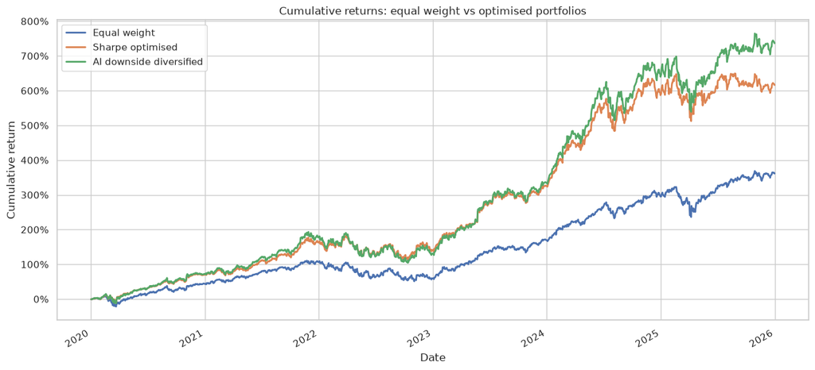

```python
portfolio_weights = pd.concat(
    [
        equal_weights.rename("Equal weight"),
        sharpe_weights.rename("Sharpe optimised"),
        ai_weights.rename("AI downside diversified"),
    ],
    axis=1,
)

portfolio_return_frame = pd.DataFrame(
    {
        "Equal weight": portfolio_returns(selected_returns, equal_weights),
        "Sharpe optimised": sharpe_returns,
        "AI downside diversified": ai_returns,
    }
)

portfolio_stats = portfolio_return_frame.apply(performance_stats)
cumulative_portfolio_returns = (1 + portfolio_return_frame).cumprod() - 1

display(portfolio_weights.T.style.format("{:.2%}"))
display(portfolio_stats.T.style.format(stats_format))

ax = cumulative_portfolio_returns.plot(figsize=(13, 6), linewidth=2)
ax.set_title("Cumulative returns: equal weight vs optimised portfolios")
ax.set_xlabel("Date")
ax.set_ylabel("Cumulative return")
ax.yaxis.set_major_formatter(plt.FuncFormatter(lambda value, _: f"{value:.0%}"))
plt.tight_layout()
plt.show()

best_portfolio = portfolio_stats.loc["Sharpe ratio"].idxmax()
best_cumulative_portfolio = portfolio_stats.loc["Cumulative return"].idxmax()
best_drawdown_portfolio = portfolio_stats.loc["Maximum drawdown"].idxmax()
```

Interpretation: the highest realised Sharpe ratio is produced by the Sharpe optimised portfolio, while the highest cumulative return is produced by the AI downside diversified portfolio. The least severe maximum drawdown is produced by the Sharpe optimised portfolio. This is the main portfolio-management trade-off. A mandate that prioritises capital growth might prefer the highest cumulative-return portfolio, but an asset manager setting up a durable client portfolio should care about risk-adjusted return and drawdown resilience. I therefore treat the Sharpe result as the primary recommendation and the AI result as a check on whether that recommendation is overly dependent on concentration.

## Analysis: Overall interpretation

The central finding is that this is not a balanced return opportunity across ten similar stocks; it is a portfolio dominated by a small number of very strong contributors. On raw closing prices, the strongest increase was NVDA at 3009.50%, while the weakest was UNH at 12.86%. That dispersion changes how I interpret the whole assessment. Equal weighting is defensible because it avoids overconfidence, but it is inefficient when the historical evidence shows such a wide gap between leaders and laggards. Optimisation is therefore useful, but only if it improves capital allocation without simply chasing the biggest past winner.

The Bollinger Bands Mean Reversion strategy is useful as a diagnostic tool, but the backtest does not justify applying it mechanically across the portfolio. It generated 521 entries and assigned only 1 stock to the strategy-return basis. That tells me the strategy found isolated value, but not a broad edge. The reason is intuitive: a mean-reversion system sells strength and buys weakness, while this sample rewarded staying invested in persistent winners such as NVDA. For a portfolio manager, the main risk of the strategy is therefore opportunity cost, not just daily volatility.

From a portfolio perspective, the average pairwise return correlation of 0.42 means the stocks diversify each other, but not enough to remove market-cycle risk. The equal-weight portfolio's Sharpe ratio of 1.14 is already strong, so the optimiser has to clear a meaningful hurdle. The Sharpe-optimised portfolio does clear that hurdle, but the improvement comes with higher concentration. My interpretation is that the portfolio is investable only with explicit risk limits: the best answer is not "buy the highest-return stocks", but "tilt toward the strongest risk-adjusted contributors while keeping concentration capped and monitoring drawdowns."

## Reporting: Final report

I recommend the **Sharpe optimised** portfolio, with the following proposed weights: NVDA 30.62%, UNH 30.56%, COST 22.92%, XOM 11.50%, GOOGL 4.40%, META 0.00%, JPM 0.00%, AAPL 0.00%, MSFT 0.00%, AMZN 0.00%. My recommendation is not based on the highest raw return alone; it is based on the best balance between return, volatility, drawdown, and concentration. The recommended portfolio produced a cumulative return of 616.13%, annualised return of 35.64%, annualised volatility of 23.29%, maximum drawdown of -23.98%, and Sharpe ratio of 1.53. I use the Sharpe ratio because it evaluates excess return per unit of volatility, which is more appropriate than raw return when portfolios have different risk levels (Investopedia, n.d.-b). The allocation is still concentrated, so I would present it to the investment committee as a risk-controlled tilt rather than as a fully diversified core equity portfolio.

Based on the Bollinger Bands Mean Reversion backtest, I would trade **UNH** using the strategy and hold the remaining **9** stocks on a buy-and-hold basis. The key investment point is selectivity: the strategy is not weak because it never works; it is weak as a portfolio-wide rule because it gives up too much participation in trending winners. The best strategy result was UNH at 118.82%, but the strongest buy-and-hold result was NVDA at 3023.39%. That gap shows the opportunity cost of forcing a mean-reversion framework onto stocks whose main return driver was persistent upward momentum. I would therefore treat the Bollinger signal as a tactical overlay only when the individual stock evidence is strong, not as the default engine of portfolio returns. Since the analysis uses adjusted close prices, the return comparison is not distorted by dividends or stock splits, which is important for historical return analysis (Investopedia, n.d.-a). The raw data was sourced with `yfinance`, an open-source interface to Yahoo Finance's publicly available APIs for research and educational use (Aroussi, 2025).

The AI-generated optimiser adds value mainly as a challenge to the Sharpe optimiser, not as a black-box replacement for it. The Sharpe portfolio asks, "which weights gave the best return per unit of total volatility?" The AI objective asks a more risk-management-oriented question: "can we keep attractive returns while penalising downside losses and concentration?" That distinction is useful because the recommended Sharpe allocation is still concentrated, so a second optimiser helps test whether the conclusion depends too heavily on one risk definition. The AI allocation was NVDA 35.00%, UNH 25.14%, COST 17.64%, GOOGL 11.38%, XOM 7.74%, JPM 3.11%, AMZN 0.00%, META 0.00%, MSFT 0.00%, AAPL 0.00%, compared with the Sharpe allocation of NVDA 30.62%, UNH 30.56%, COST 22.92%, XOM 11.50%, GOOGL 4.40%, META 0.00%, JPM 0.00%, AAPL 0.00%, MSFT 0.00%, AMZN 0.00%. I would not choose the AI allocation automatically because the penalty parameters are judgement-based, but I would use it as a governance tool: if the AI portfolio achieved similar performance with lower downside risk or less concentration, it would strengthen the investment case; if it produced materially worse results, it would reveal the cost of prioritising smoother risk over maximum Sharpe. The implementation remains credible because it uses the same transparent `scipy.optimize.minimize` structure and constrained minimisation workflow as the standard optimiser (SciPy Developers, 2026).

Overall, the firm should consider the portfolio, but the investment case should be framed as conditional rather than definitive. The historical results are strong, yet they come from a period that rewarded large-cap growth and technology exposure, so the backtest may overstate future performance if market leadership rotates. The portfolio is most attractive if the firm's mandate allows concentrated exposure to proven winners while enforcing maximum-weight, sector, and drawdown controls. Before committing capital, I would run an out-of-sample test, include transaction costs and tax assumptions, and stress test the allocation under a weaker technology market. My final recommendation is therefore to move this portfolio to due diligence, not immediate full-scale implementation.

**Reference list**

Aroussi, R. (2025). *yfinance documentation: Download market data from Yahoo! Finance's API*. https://ranaroussi.github.io/yfinance/

Investopedia. (n.d.-a). *How to calculate a stock's adjusted closing price*. https://www.investopedia.com/ask/answers/06/adjustedclosingprice.asp

Investopedia. (n.d.-b). *Sharpe ratio: Definition, formula, and examples*. https://www.investopedia.com/terms/s/sharperatio.asp

SciPy Developers. (2026). *scipy.optimize.minimize*. SciPy v1.18.0 Manual. https://docs.scipy.org/doc/scipy/reference/generated/scipy.optimize.minimize.html